# Analysis of 3k T cells from cancer

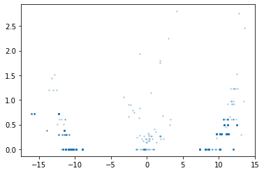

```python
# Do some statistics to compare between groupings for all clonotypes - Khi square and Fischer's came to my mind now, but any sugestion is welcome (also not sure if clonotype size or presence should be used)

from scipy.stats import fisher_exact

clt_stats, clt_selection, volcano = [], [], [[], []]
if control_label is None:
    control_label = 'Background'
for hue, cases, controls, ncase, ncontrol in case_control_groups:
    if hue is None:
        hue = 'All'
    tdf1 = clonotype_presence.loc[cases, ]
    tdf2 = clonotype_presence.loc[controls, ]
    suspects = set(tdf1.loc[:, tdf1.sum() > 0].columns.values.tolist() + tdf2.loc[:, tdf2.sum() > 0].columns.values.tolist())
    for suspect in suspects:
        case_sizes = tdf1[suspect]
        control_sizes = tdf2[suspect]
        rel_case_sizes = case_sizes/np.array(ncase)
        rel_control_sizes = control_sizes/np.array(ncontrol)
        np.mean((case_sizes+0.0001)/np.array(ncase))
        case_mean_freq = np.mean((case_sizes+0.0001)/np.array(ncase))
        case_presence = case_sizes.sum()
        case_absence = ncase.sum() - case_presence
        control_mean_freq = np.mean((control_sizes+0.0001)/np.array(ncontrol))
        control_presence = control_sizes.sum()
        control_absence = ncontrol.sum() - control_presence
        oddsratio, p = fisher_exact([[case_presence, control_presence], [case_absence, control_absence]])
        logfoldchange = np.log2(case_mean_freq/control_mean_freq)
        volcano[0].append(logfoldchange)
        volcano[1].append(-np.log10(p))
        clt_selection.append([p, suspect])
        for e in rel_case_sizes.index.values:
            clt_stats.append((suspect, hue, target_label, rel_case_sizes[e], e))
        for e in rel_control_sizes.index.values:
            clt_stats.append((suspect, hue, control_label, rel_control_sizes[e], e))

plt.scatter(*volcano, s=2, alpha=0.3)
```

```python
# Choose the most inbalanced clonotypes

clt_selection.sort(key=lambda x: x[0])
clt_selection = clt_selection[:top_n]
clt_selection
```

```
[[0.0015895742965660589, '18'],
 [0.001722304402043615, '282'],
 [0.0034386951116313846, '387'],
 [0.005567890393763275, '69'],
 [0.011404478689663993, '2'],
 [0.015824695131618487, '32'],
 [0.017597095442958975, '294'],
 [0.029301432160085687, '137'],
 [0.031064830353891675, '61'],
 [0.03642416891506354, '1787'],
 [0.05942736349339734, '407'],
 [0.05942736349339734, '181'],
 [0.05942736349339734, '262'],
 [0.05942736349339734, '409'],
 [0.05942736349339734, '286'],
 [0.06225297223325579, '462'],
 [0.06225297223325579, '344'],
 [0.06225297223325579, '323'],
 [0.0726823997186193, '16'],
 [0.08776996261387765, '16']]
```

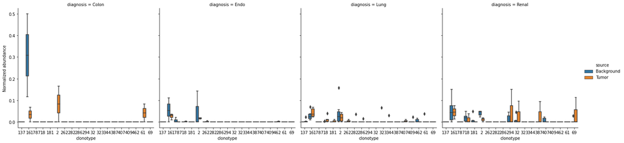

```python
# Draw clonotype size for the compared groups, accross hue - would be nice to tweak group abundances later, but now it seems a bit far

top_clonotypes = list(zip(*clt_selection))[1]

if additional_hue is None:
    tclt_df = pd.DataFrame.from_records(clt_stats, columns =[clonotype_col, target_col, 'Normalized abundance', replicate_col])
    tclt_df = tclt_df.loc[tclt_df[clonotype_col].isin(top_clonotypes), :]
    tclt_df = tclt_df.pivot_table(index=[target_col, replicate_col], columns=clonotype_col, values='Normalized abundance', fill_value=0).reset_index()
    tclt_df = pd.melt(tclt_df, id_vars=[target_col, replicate_col], value_name='Normalized abundance')
    sns.boxplot(x=clonotype_col, y='Normalized abundance', hue=target_col, data=tclt_df)
else:
    tclt_df = pd.DataFrame.from_records(clt_stats, columns =[clonotype_col, additional_hue, target_col, 'Normalized abundance', replicate_col])
    tclt_df = tclt_df.loc[tclt_df[clonotype_col].isin(top_clonotypes), :]
    tclt_df = tclt_df.pivot_table(index=[additional_hue, target_col, replicate_col], columns=clonotype_col, values='Normalized abundance', fill_value=0).reset_index()
    tclt_df = pd.melt(tclt_df, id_vars=[additional_hue, target_col, replicate_col], value_name='Normalized abundance')
    sns.factorplot(x=clonotype_col, y='Normalized abundance', hue=target_col, kind='box', col=additional_hue, data=tclt_df)
```

```python
top_n = 20
```

[figure not shown]

```python
sns.factorplot(x=clonotype_col, y='Normalized abundance', hue=target_col, kind='bar', col=additional_hue, data=tclt_df)
```

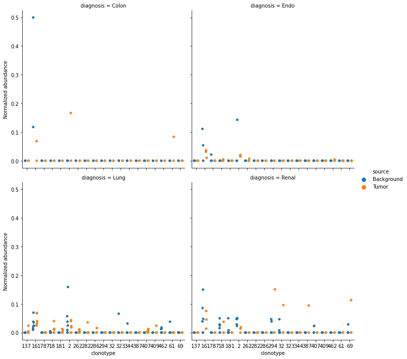

```python
sns.catplot(x=clonotype_col, y='Normalized abundance', hue=target_col, kind='strip', col=additional_hue, data=tclt_df, dodge=True, col_wrap=2)
```

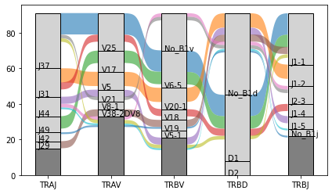

```python
# Try to show VDJ usage for one of the clonotypes only

ir.pl.vdj_usage(adata[adata.obs['clonotype'].isin(['2'])])
```

One single clonotype, as a result of convergence from different VDJ recombinations

## Comparison of gene expression in two clusters

If one finds a cluster of T cells with promising reactivity, it is a straightforward question if there is also a difference in terms of gene expression over other cells or another cluster.

```python
# Subset adata for cells that belong to either clonotype

adata.obs['grouping_for_gex'] = adata.obs['clonotype'].map({'2': 'Clonotype_2', '16': 'Clonotype_16'})
s_adata = adata[~adata.obs['grouping_for_gex'].isna()]
```

```python
# Have to do some prefiltering

adata.obs['grouping_for_gex'] = adata.obs['clonotype'].map({'2': 'Clonotype_2', '16': 'Clonotype_16'})
s_adata = adata[~adata.obs['grouping_for_gex'].isna()]
```

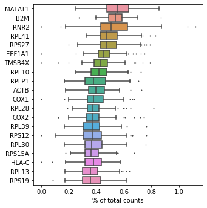

```python
# Check highest expressed genes

sc.pl.highest_expr_genes(s_adata, n_top=20, )
```

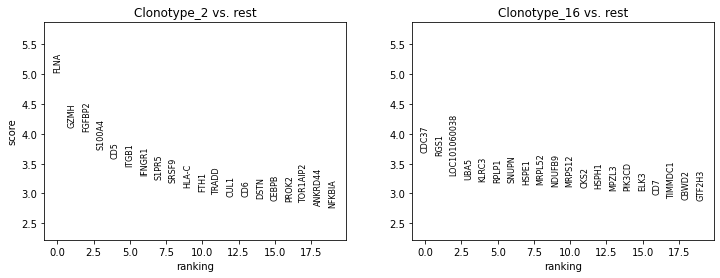

```python
# Compare gene expression between the two clonotypes

sc.tl.rank_genes_groups(s_adata, groupby='grouping_for_gex')
sc.pl.rank_genes_groups(s_adata, groupby='grouping_for_gex')
```

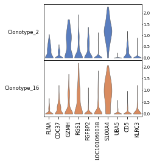

```python
# Show expression of top DE genes

deg_df = s_adata.uns['rank_genes_groups'].copy()
deg_df.pop('params')
deg_df = pd.DataFrame(deg_df)
top_deg = deg_df[0:5]['names']
top_deg = np.array([[x for x in y] for y in top_deg])
top_deg = top_deg.flatten()
sc.pl.stacked_violin(s_adata, top_deg, groupby='grouping_for_gex')
```

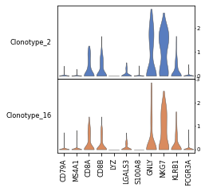

```python
# Show cell type marker genes

marker_genes = ['CD79A', 'MS4A1', 'CD8A', 'CD8B', 'LYZ',  'LGALS3', 'S100A8', 'GNLY', 'NKG7', 'KLRB1', 'FCGR3A']
sc.pl.stacked_violin(s_adata, marker_genes, groupby='grouping_for_gex')
```

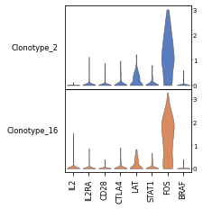

```python
# Show genes related toT cell activation

activation_genes = ['IL2', 'IL2RA', 'CD28', 'CTLA4', 'LAT', 'STAT1', 'FOS', 'BRAF'] # This is only a guessing list, but might be worth digging up the literature
sc.pl.stacked_violin(s_adata, activation_genes, groupby='grouping_for_gex')
```

It might be more a scanpy related issue, not that much our problem, but instead of putting them beneath each other as stacked violins, it would be better to put them next to each other, like grouped strippolts.

## Putting subplots together

[figure not shown]

```python
# A last comment: we might want to make it easier to make our figures multipanel

fig, axs = plt.subplots(2, 2, figsize=(7, 11))
axs = axs.flatten()
tissues = ['Lung', 'Colon', 'Endo', 'Renal']
for i in range(len(tissues)):
    axs[i] = ir.pl.group_abundance(adata[adata.obs['patient'].str[:-1] == tissues[i]], groupby="clonotype", target_col="patient", max_cols=10, ax=axs[i])
```

https://github.com/theislab/scanpy/issues/397